# In the following data nc = number of claims tp = total payment for all the claims in thousands of Rupees

```python
import pandas as pd
import numpy as np

import matplotlib.pyplot as plt
%matplotlib inline
```

```python
filename = 'data.csv'
dataset = pd.read_csv(filename)
dataset.head()
```

|  | nc | tp |
| --- | --- | --- |
| 0 | 108 | 392.5 |
| 1 | 19 | 46.2 |
| 2 | 13 | 15.7 |
| 3 | 124 | 422.2 |
| 4 | 40 | 119.4 |

```python
dataset.shape
```

```
(63, 2)
```

# Converting column nc to float

```python
dataset['nc'] = dataset['nc'].astype('float64')
dataset.head()
```

|  | nc | tp |
| --- | --- | --- |
| 0 | 108.0 | 392.5 |
| 1 | 19.0 | 46.2 |
| 2 | 13.0 | 15.7 |
| 3 | 124.0 | 422.2 |
| 4 | 40.0 | 119.4 |

# split the dataset into train and test

```python
traindf = pd.DataFrame(dataset[:44])
testdf = pd.DataFrame(dataset[45:])
```

```python
traindf.shape
```

```
(44, 2)
```

```python
testdf.shape
```

```
(18, 2)
```

Calculate the mean of column nc and tp

```python
mean_nc,mean_tp = traindf['nc'].mean(),traindf['tp'].mean()
print(mean_nc,mean_tp)
```

```
23.09090909090909 92.60227272727275
```

calaculate variance of column nc

```python
var_nc = traindf.loc[:,'nc'].var()
print(var_nc)
```

```
693.3868921775897
```

calculate co variance of column nc and tp relative

```python
covall = traindf.cov()
cov_nc_tp = covall['nc'][1]
print(cov_nc_tp)
```

```
2398.86490486258
```

lets try to fit this data into tp = w*nc+b where w = weight of column nc and b = bias so by formula w = cov_nc_tp / var_nc b = mean_tp - mean_nc* w

```python
w = cov_nc_tp/var_nc
b= mean_tp - mean_nc*w
print(w,b)
```

```
3.459634054126573 12.7161772956228
```

Add a new column to original train dataset named tppred and add the predicted value in that column

```python
traindf['tppred'] = b+w*traindf['nc']
traindf.head()
```

|  | nc | tp | tppred |
| --- | --- | --- | --- |
| 0 | 108.0 | 392.5 | 386.356655 |
| 1 | 19.0 | 46.2 | 78.449224 |
| 2 | 13.0 | 15.7 | 57.691420 |
| 3 | 124.0 | 422.2 | 441.710800 |
| 4 | 40.0 | 119.4 | 151.101539 |

# Calculate the Root Mean Square error for columns tp and tppred for the prediction error idea

```python
rsme = ((traindf.tppred-traindf.tp)**2).mean()**.5
print(rsme)
```

```
27.531839823905834
```

Plot the graph

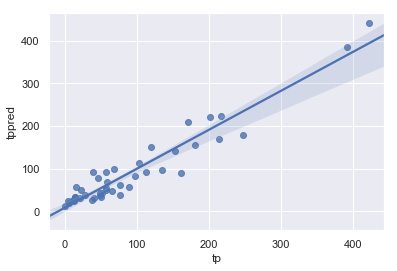

```python
import seaborn as sns
import warnings
warnings.simplefilter(action='ignore', category=FutureWarning)
sns.set(color_codes=True)
sns.regplot(x='tp',y='tppred',data=traindf)
```

# From the above graph we can see that tp and tppred are not too far apart. Thus our prediction is good

Now apply this model on test data

```python
testdf['tppred'] = b+w*testdf['nc']
testdf.head()
```

|  | nc | tp | tppred |
| --- | --- | --- | --- |
| 45 | 41.0 | 73.4 | 154.561174 |
| 46 | 11.0 | 21.3 | 50.772152 |
| 47 | 27.0 | 92.6 | 106.126297 |
| 48 | 8.0 | 76.1 | 40.393250 |
| 49 | 3.0 | 39.9 | 23.095079 |

```python
rsme = ((testdf.tppred-testdf.tp)**2).mean()**.5
print(rsme)
```

```
50.74135173090564
```

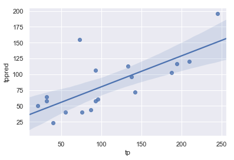

```python
import seaborn as sns
import warnings
warnings.simplefilter(action='ignore', category=FutureWarning)
sns.set(color_codes=True)
sns.regplot(x='tp',y='tppred',data=testdf)
```

# So we can see that except few noise data other predicted data is not too far from original data